# 04 - Análisis de dispersión de valores por Banda (Micasense RedEdge P Dual) en imágenes del panel de calibración

Autor/a

Christian Rueda-Ayala

Fecha de publicación

22 de septiembre de 2025

# 1 Resumen

Este reporte documenta el flujo de análisis para la evaluación de la dispersión de valores de píxeles por banda en imágenes adquiridas con la Micasense RedEdge P Dual. El objetivo principal es caracterizar la respuesta radiométrica de las distintas bandas espectrales y verificar la consistencia de los datos registrados en una ROI cuadrada de 51 píxeles, correspondiente a la fecha de referencia 2025-06-20.

# 2 Procedimiento

## 2.1 Carga de datos y ordenamiento

Se importan las mediciones de salida en formato CSV, se organizan según la información oficial de la cámara (sufijo e índice) y se convierten los valores almacenados en formato JSON a listas numéricas para su análisis.

**Código**

```python
# Librerías/módulos requeridos
import pandas as pd
import numpy as np
import matplotlib.pyplot as plt
import json

# Funciones y variables auxiliares

# Función de suavizado de la envolvente
def gaussian_kernel(sigma, length=None):
    if sigma <= 0:
        return np.array([1.0])
    if length is None:
        length = int(max(3, np.ceil(sigma * 8)))
    if length % 2 == 0:
        length += 1
    x = np.arange(length) - (length // 2)
    g = np.exp(-0.5 * (x / sigma) ** 2)
    return g / g.sum()

# Vector de colores para gráficos
colors = {'Blue':'blue', 'Green':'green', 'Red':'red', 'NIR':'darkred', 'Red Edge':'orangered',
          'Blue-444':'deepskyblue', 'Green-531':'lime', 'Red-650':'pink','Red Edge 705':'coral','Red Edge 740':'indianred'}

# Carga de los datos
data = pd.read_csv("~/workfiles/Gitlab/micasense_band_check/scripts/miproy/SALIDAS/1_med_roi.csv")

# Convertir la columna 'values' (string JSON) a listas de floats
data["values_list"] = data["values"].apply(lambda x: json.loads(x))
```

## 2.2 Ordenamiento

Se ordenan datos según el índice de la imagen o según la info oficial de la cámara:

**Código**

```python
# Ordenamiento de los datos según el sufijo de las imágenes: IMG_0000_sufijo.tif -> [1, 2, 3, 4, 5, 6, 7, 8, 9, 10, 11]
data = data.sort_values(by = "sufijo")
data = data.reset_index()
#display(data)
```

## 2.3 Visualización de la dispersión y tendencias por banda:

Se grafican los valores individuales de píxeles para cada longitud de onda central (CWL), lo que permite observar la variabilidad interna de cada banda:

**Código**

```
Banda: Blue (475.0 nm) -> Color asignado: blue
Banda: Green (560.0 nm) -> Color asignado: green
Banda: Red (668.0 nm) -> Color asignado: red
Banda: NIR (842.0 nm) -> Color asignado: darkred
Banda: Red Edge (717.0 nm) -> Color asignado: orangered
Banda: Blue-444 (444.0 nm) -> Color asignado: deepskyblue
Banda: Green-531 (531.0 nm) -> Color asignado: lime
Banda: Red-650 (650.0 nm) -> Color asignado: pink
Banda: Red Edge 705 (705.0 nm) -> Color asignado: coral
Banda: Red Edge 740 (740.0 nm) -> Color asignado: indianred
```

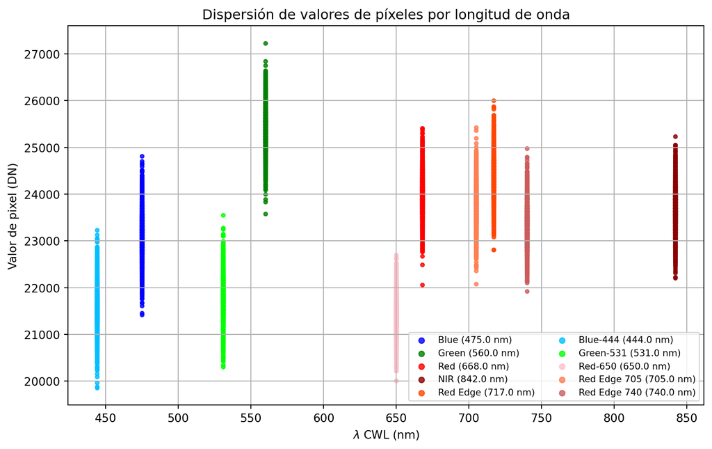

```python
# Crear figura
plt.figure(figsize=(10,6))

# Graficar todos los valores de cada ROI
for i, row in data.iterrows():
    banda = row['banda']
    cwl = row['cwl']
    vals = row['values_list']

    # Usar el diccionario para asignar color según la banda
    color = colors.get(banda, 'black')  # Si no encuentra, usa negro por defecto

    print(f"Banda: {banda} ({cwl} nm) -> Color asignado: {color}")

    plt.scatter([cwl]*len(vals), vals, c=color, alpha=0.8, s=10,
                label=f"{banda} ({cwl} nm)")

plt.xlabel("$\\lambda$ CWL (nm)")
plt.ylabel("Valor de pixel (DN)")
plt.title("Dispersión de valores de píxeles por longitud de onda")
plt.legend(loc='lower right', prop={'size': 8}, markerscale=1.5, ncol=2)
plt.grid(True)
plt.show()
```

Se calculan y representan los valores medios por ROI, ofreciendo una visión resumida del comportamiento espectral por banda.

**Código**

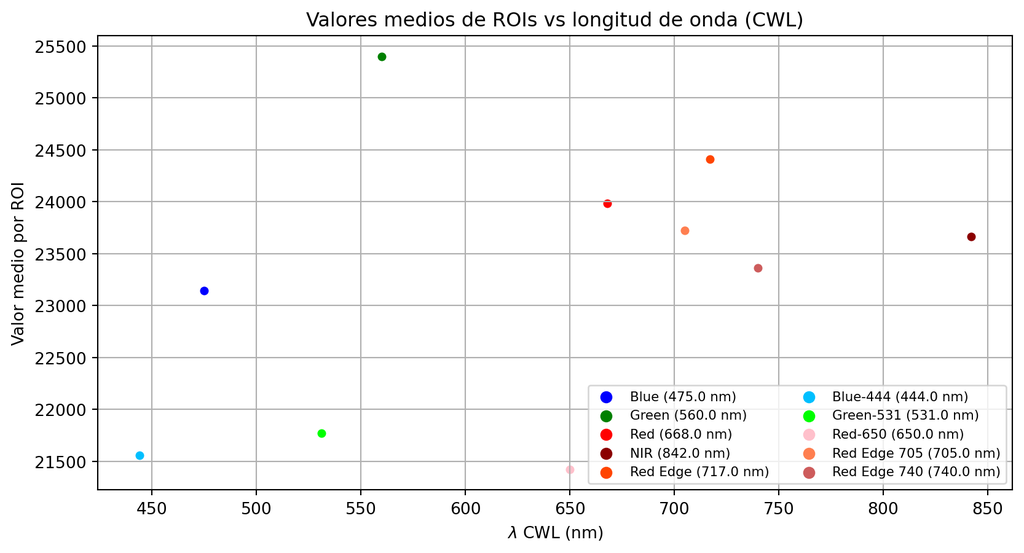

```python
# Crear gráfico
plt.figure(figsize=(10,5))

# Graficar cada fila con su leyenda
for i, row in data.iterrows():
    plt.scatter(row["cwl"], row["mean"], c=colors.get(row['banda'], 'black'), s= 18, label=f"{row['banda']} ({row['cwl']} nm)")

plt.xlabel("$ \\lambda$ CWL (nm)")
plt.ylabel("Valor medio por ROI")
plt.title("Valores medios de ROIs vs longitud de onda (CWL)")
plt.legend(loc= 'lower right', prop={'size': 8}, markerscale=1.5, ncol=2)
plt.grid(True)
plt.show()
```

## 2.4 Análisis de distribuciones

Se generan histogramas de frecuencias para cada banda, con el fin de explorar la forma de la distribución radiométrica, detectar posibles sesgos y evaluar la homogeneidad en los datos.

**Código**

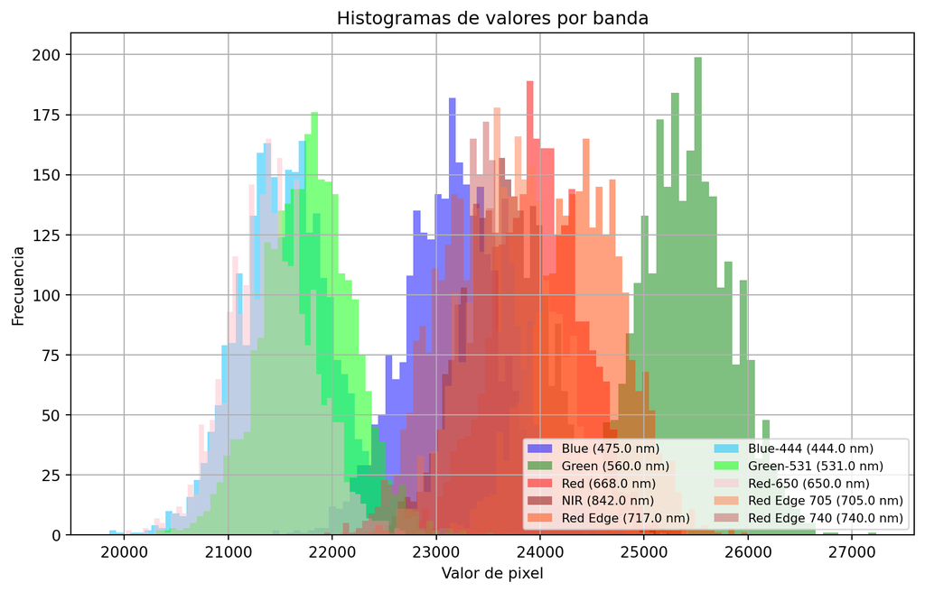

```python
#Crear gráfico
plt.figure(figsize=(10,6))

# 2) Graficar distribuciones completas (valores individuales de cada ROI)
for i, row in data.iterrows():
    plt.hist(row["values_list"], bins=50, alpha=0.5, color = colors.get(row['banda'], 'black'), label=f"{row['banda']} ({row['cwl']} nm)")

plt.xlabel("Valor de pixel")
plt.ylabel("Frecuencia")
plt.title("Histogramas de valores por banda")
plt.legend(loc= 'lower right', prop={'size': 8}, markerscale=1.5, ncol=2)
plt.grid(True)
plt.show()
```

Considerando solo la envolvente de los histogramas, con suavizado gaussiano:

**Código**

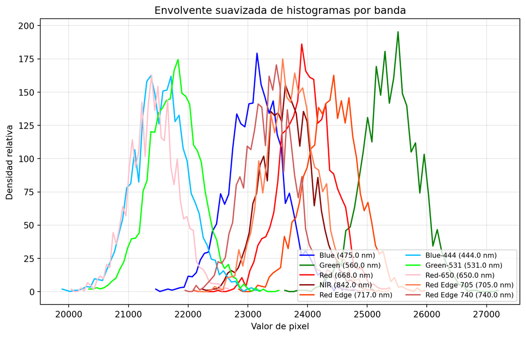

```python
# Crear gráfico
plt.figure(figsize=(10,6))

# Recorrer bandas y graficar la envolvente
for i, row in data.iterrows():
    vals = np.array(row["values_list"], dtype=float)
    if vals.size == 0:
        continue

    vmin, vmax = np.nanmin(vals), np.nanmax(vals)
    counts, edges = np.histogram(vals, bins=50, range=(vmin, vmax))
    centers = (edges[:-1] + edges[1:]) / 2.0

    # suavizar envolvente
    kernel = gaussian_kernel(sigma=0.4, length=25)
    smooth = np.convolve(counts.astype(float), kernel, mode="same")

    # graficar curva
    plt.plot(centers, smooth, color=colors.get(row['banda'], 'black'), linewidth=1.5,
             label=f"{row['banda']} ({row['cwl']} nm)")

plt.xlabel("Valor de pixel")
plt.ylabel("Densidad relativa")
plt.title("Envolvente suavizada de histogramas por banda")
plt.legend(loc='lower right', prop={'size': 8}, markerscale=1.5, ncol=2)
plt.grid(True, alpha=0.3)
plt.show()
```

### 2.4.1 Comparativa de bandas específicas

#### 2.4.1.1 Blue 475 (RED) vs Blue 444 (BLUE)

**Código**

```
Datos Blue: min = 21424.0, max = 24816.0, media = 23143.14186851211, std = 468.7126826465332
Datos Blue-444: min = 19856.0, max = 23232.0, media = 21554.52210688197, std = 456.37617739500513
```

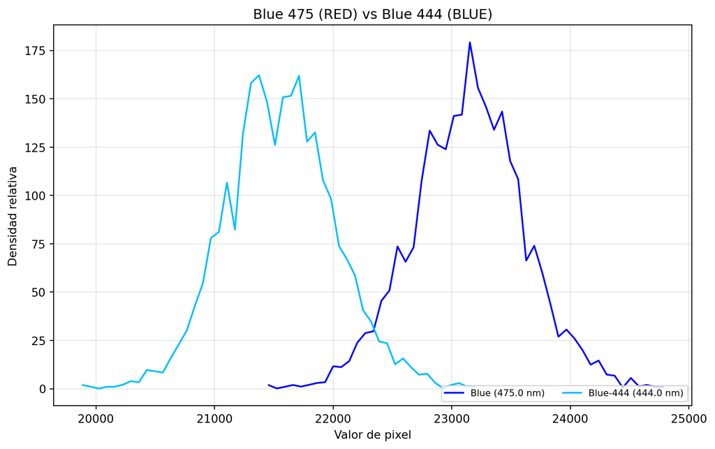

```python
datos = pd.concat([data[data['sufijo']==1], data[data['sufijo']==7]])
# Crear gráfico
plt.figure(figsize=(10,6))

# Recorrer bandas y graficar la envolvente
for i, row in datos.iterrows():
    vals = np.array(row["values_list"], dtype=float)
    if vals.size == 0:
        continue

    vmin, vmax = np.nanmin(vals), np.nanmax(vals)
    counts, edges = np.histogram(vals, bins=50, range=(vmin, vmax))
    centers = (edges[:-1] + edges[1:]) / 2.0

    # suavizar envolvente
    kernel = gaussian_kernel(sigma=0.4, length=25)
    smooth = np.convolve(counts.astype(float), kernel, mode="same")

    # Imprimir valores estadísticos
    print(f"Datos {row['banda']}: min = {vmin}, max = {vmax}, media = {row['mean']}, std = {row['std']}")


    # graficar curva
    plt.plot(centers, smooth, color=colors.get(row['banda'], 'black'), linewidth=1.5,
             label=f"{row['banda']} ({row['cwl']} nm)")

plt.xlabel("Valor de pixel")
plt.ylabel("Densidad relativa")
plt.title("Blue 475 (RED) vs Blue 444 (BLUE)")
plt.legend(loc='lower right', prop={'size': 8}, markerscale=1.5, ncol=2)
plt.grid(True, alpha=0.3)
plt.show()
```

#### 2.4.1.2 Green 560 (RED) vs Green 531 (BLUE)

**Código**

```
Datos Green: min = 23584.0, max = 27232.0, media = 25399.11726259131, std = 444.9561375403608
Datos Green-531: min = 20304.0, max = 23552.0, media = 21769.46097654748, std = 423.8154518328373
```

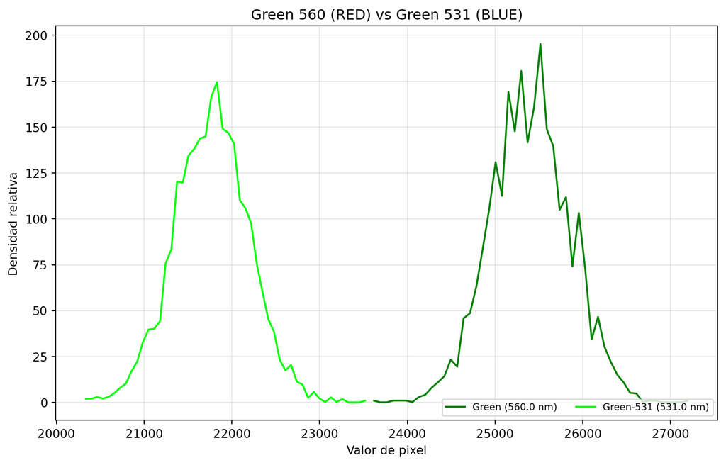

```python
datos = pd.concat([data[data['sufijo']==2], data[data['sufijo']==8]])
# Crear gráfico
plt.figure(figsize=(10,6))

# Recorrer bandas y graficar la envolvente
for i, row in datos.iterrows():
    vals = np.array(row["values_list"], dtype=float)
    if vals.size == 0:
        continue

    vmin, vmax = np.nanmin(vals), np.nanmax(vals)
    counts, edges = np.histogram(vals, bins=50, range=(vmin, vmax))
    centers = (edges[:-1] + edges[1:]) / 2.0

    # suavizar envolvente
    kernel = gaussian_kernel(sigma=0.4, length=25)
    smooth = np.convolve(counts.astype(float), kernel, mode="same")

    # Imprimir valores estadísticos
    print(f"Datos {row['banda']}: min = {vmin}, max = {vmax}, media = {row['mean']}, std = {row['std']}")

    # graficar curva
    plt.plot(centers, smooth, color=colors.get(row['banda'], 'black'), linewidth=1.5,
             label=f"{row['banda']} ({row['cwl']} nm)")

plt.xlabel("Valor de pixel")
plt.ylabel("Densidad relativa")
plt.title("Green 560 (RED) vs Green 531 (BLUE)")
plt.legend(loc='lower right', prop={'size': 8}, markerscale=1.5, ncol=2)
plt.grid(True, alpha=0.3)
plt.show()
```

#### 2.4.1.3 Red 668 (RED) vs Red 650 (BLUE)

**Código**

```
Datos Red: min = 22064.0, max = 25408.0, media = 23982.474432910418, std = 428.68109855226186
Datos Red-650: min = 20016.0, max = 22704.0, media = 21422.148404459826, std = 397.8578755838834
```

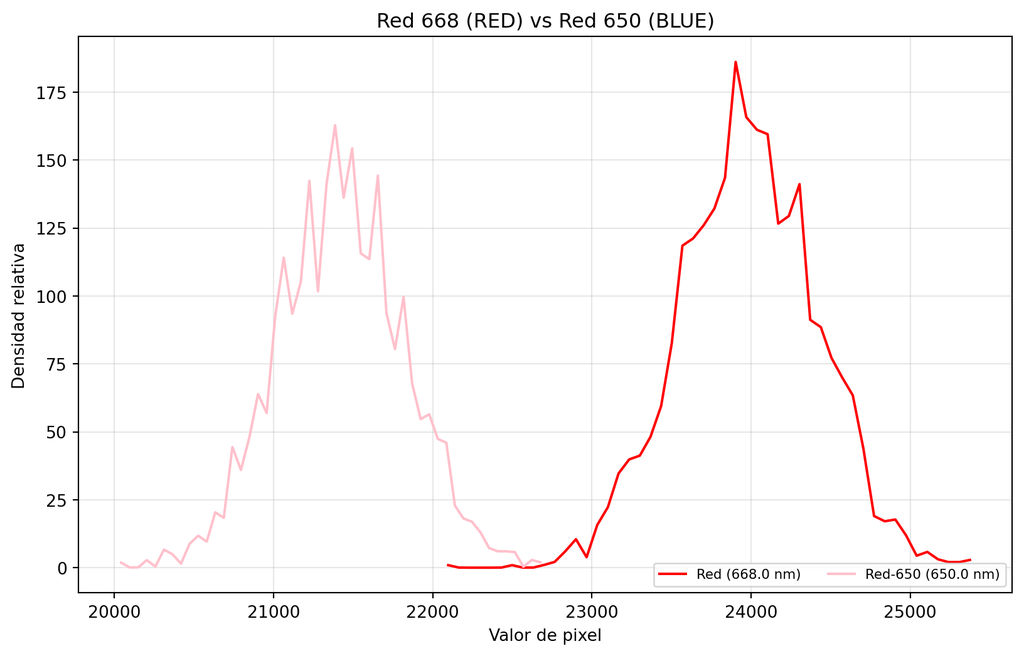

```python
datos = pd.concat([data[data['sufijo']==3], data[data['sufijo']==9]])
# Crear gráfico
plt.figure(figsize=(10,6))

# Recorrer bandas y graficar la envolvente
for i, row in datos.iterrows():
    vals = np.array(row["values_list"], dtype=float)
    if vals.size == 0:
        continue

    vmin, vmax = np.nanmin(vals), np.nanmax(vals)
    counts, edges = np.histogram(vals, bins=50, range=(vmin, vmax))
    centers = (edges[:-1] + edges[1:]) / 2.0

    # suavizar envolvente
    kernel = gaussian_kernel(sigma=0.4, length=25)
    smooth = np.convolve(counts.astype(float), kernel, mode="same")

    # Imprimir valores estadísticos
    print(f"Datos {row['banda']}: min = {vmin}, max = {vmax}, media = {row['mean']}, std = {row['std']}")

    # graficar curva
    plt.plot(centers, smooth, color=colors.get(row['banda'], 'black'), linewidth=1.5,
             label=f"{row['banda']} ({row['cwl']} nm)")

plt.xlabel("Valor de pixel")
plt.ylabel("Densidad relativa")
plt.title("Red 668 (RED) vs Red 650 (BLUE)")
plt.legend(loc='lower right', prop={'size': 8}, markerscale=1.5, ncol=2)
plt.grid(True, alpha=0.3)
plt.show()
```

#### 2.4.1.4 NIR 842 (RED) vs Red Edge 740 (BLUE)

**Código**

```
Datos NIR: min = 22208.0, max = 25232.0, media = 23664.73817762399, std = 428.7410316741873
Datos Red Edge 740: min = 21920.0, max = 24976.0, media = 23364.68127643214, std = 421.39118599382255
```

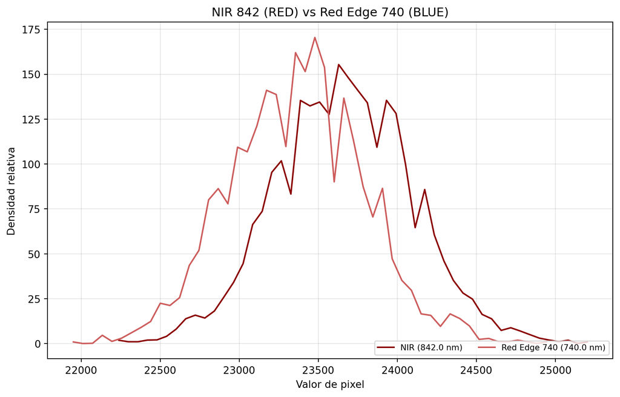

```python
datos = pd.concat([data[data['sufijo']==4], data[data['sufijo']==11]])
# Crear gráfico
plt.figure(figsize=(10,6))

# Recorrer bandas y graficar la envolvente
for i, row in datos.iterrows():
    vals = np.array(row["values_list"], dtype=float)
    if vals.size == 0:
        continue

    vmin, vmax = np.nanmin(vals), np.nanmax(vals)
    counts, edges = np.histogram(vals, bins=50, range=(vmin, vmax))
    centers = (edges[:-1] + edges[1:]) / 2.0

    # suavizar envolvente
    kernel = gaussian_kernel(sigma=0.4, length=25)
    smooth = np.convolve(counts.astype(float), kernel, mode="same")

    # Imprimir valores estadísticos
    print(f"Datos {row['banda']}: min = {vmin}, max = {vmax}, media = {row['mean']}, std = {row['std']}")

    # graficar curva
    plt.plot(centers, smooth, color=colors.get(row['banda'], 'black'), linewidth=1.5,
             label=f"{row['banda']} ({row['cwl']} nm)")

plt.xlabel("Valor de pixel")
plt.ylabel("Densidad relativa")
plt.title("NIR 842 (RED) vs Red Edge 740 (BLUE)")
plt.legend(loc='lower right', prop={'size': 8}, markerscale=1.5, ncol=2)
plt.grid(True, alpha=0.3)
plt.show()
```

#### 2.4.1.5 Red Edge 717 (RED) vs Red Edge 705 (BLUE)

**Código**

```
Datos Red Edge: min = 22816.0, max = 26000.0, media = 24410.937331795463, std = 442.7991173844333
Datos Red Edge 705: min = 22080.0, max = 25424.0, media = 23725.883890811227, std = 438.23694912835055
```

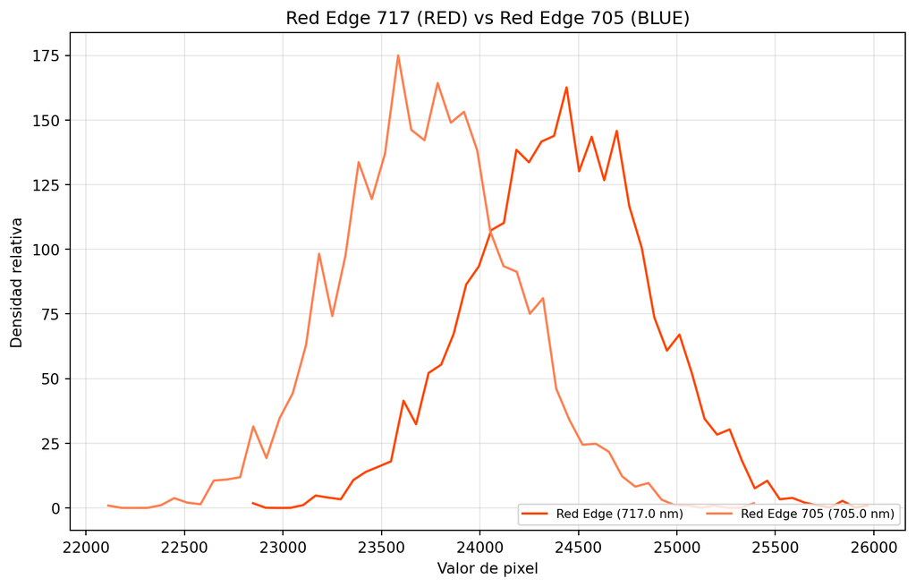

```python
datos = pd.concat([data[data['sufijo']==5], data[data['sufijo']==10]])
# Crear gráfico
plt.figure(figsize=(10,6))

# Recorrer bandas y graficar la envolvente
for i, row in datos.iterrows():
    vals = np.array(row["values_list"], dtype=float)
    if vals.size == 0:
        continue

    vmin, vmax = np.nanmin(vals), np.nanmax(vals)
    counts, edges = np.histogram(vals, bins=50, range=(vmin, vmax))
    centers = (edges[:-1] + edges[1:]) / 2.0

    # suavizar envolvente
    kernel = gaussian_kernel(sigma=0.4, length=25)
    smooth = np.convolve(counts.astype(float), kernel, mode="same")

    # Imprimir valores estadísticos
    print(f"Datos {row['banda']}: min = {vmin}, max = {vmax}, media = {row['mean']}, std = {row['std']}")

    # graficar curva
    plt.plot(centers, smooth, color=colors.get(row['banda'], 'black'), linewidth=1.5,
             label=f"{row['banda']} ({row['cwl']} nm)")

plt.xlabel("Valor de pixel")
plt.ylabel("Densidad relativa")
plt.title("Red Edge 717 (RED) vs Red Edge 705 (BLUE)")
plt.legend(loc='lower right', prop={'size': 8}, markerscale=1.5, ncol=2)
plt.grid(True, alpha=0.3)
plt.show()
```

#### 2.4.1.6 Histograma con media y desviación estándar

Si se considera solo la envolvente del histograma, con la media $(\mu)$ y desviación estándar $(\sigma)$:

**Código**

```
Datos Blue: min = 21424.0, max = 24816.0, media = 23143.14186851211, std = 468.7126826465332
Datos Green: min = 23584.0, max = 27232.0, media = 25399.11726259131, std = 444.95613754036077
Datos Red: min = 22064.0, max = 25408.0, media = 23982.474432910418, std = 428.68109855226186
Datos NIR: min = 22208.0, max = 25232.0, media = 23664.73817762399, std = 428.7410316741873
Datos Red Edge: min = 22816.0, max = 26000.0, media = 24410.937331795463, std = 442.7991173844333
Datos Blue-444: min = 19856.0, max = 23232.0, media = 21554.52210688197, std = 456.37617739500513
Datos Green-531: min = 20304.0, max = 23552.0, media = 21769.46097654748, std = 423.8154518328373
Datos Red-650: min = 20016.0, max = 22704.0, media = 21422.148404459822, std = 397.85787558388347
Datos Red Edge 705: min = 22080.0, max = 25424.0, media = 23725.883890811227, std = 438.23694912835055
Datos Red Edge 740: min = 21920.0, max = 24976.0, media = 23364.68127643214, std = 421.39118599382255
```

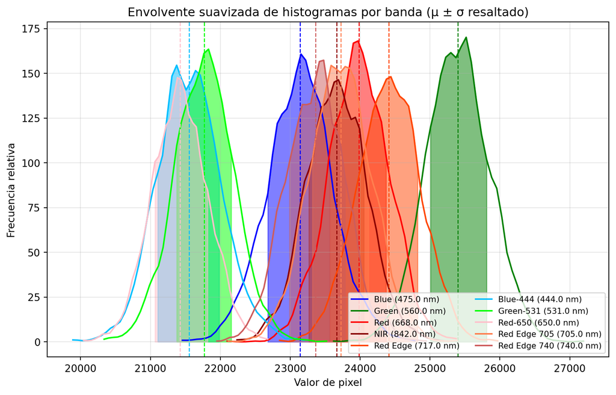

```python
# Crear gráfico
plt.figure(figsize=(10,6))

for i, row in data.iterrows():
    vals = np.array(row["values_list"], dtype=float)
    if vals.size == 0:
        continue

    vmin, vmax = np.nanmin(vals), np.nanmax(vals)
    counts, edges = np.histogram(vals, bins=50, range=(vmin, vmax))
    centers = (edges[:-1] + edges[1:]) / 2.0

    # suavizar
    kernel = gaussian_kernel(sigma=1.0, length=25)
    smooth = np.convolve(counts.astype(float), kernel, mode="same")

    # calcular media y desviación estándar
    mu = np.nanmean(vals)
    sd = np.nanstd(vals)
    print(f"Datos {row['banda']}: min = {vmin}, max = {vmax}, media = {mu}, std = {sd}")


    # curva principal
    plt.plot(centers, smooth, color=colors.get(row['banda'], 'black'), linewidth=1.5,
             label=f"{row['banda']} ({row['cwl']} nm)")

    # sombrear solo en el rango μ ± σ
    mask = (centers >= mu - sd) & (centers <= mu + sd)
    plt.fill_between(centers[mask], 0, smooth[mask],
                     color=colors.get(row['banda'], 'black'), alpha=0.5)

    # opcional: marcar la media con línea
    plt.axvline(mu, color=colors.get(row['banda'], 'black'), linestyle="--", linewidth=1)

plt.xlabel("Valor de pixel")
plt.ylabel("Frecuencia relativa")
plt.title("Envolvente suavizada de histogramas por banda (μ ± σ resaltado)")
plt.legend(loc='lower right', prop={'size': 8}, markerscale=1.5, ncol=2)
plt.grid(True, alpha=0.3)
plt.show()
```

### 2.4.2 Comparativa según EXIF

**Código**

```
Datos Red: min = 22064.0, max = 25408.0, media = 23982.474432910418, std = 428.68109855226186
Datos Red Edge 705: min = 22080.0, max = 25424.0, media = 23725.883890811227, std = 438.23694912835055
```

[figure not shown]

```python
datos = pd.concat([data[data['sufijo']==3], data[data['sufijo']==10]])
# Crear gráfico
plt.figure(figsize=(10,6))

# Recorrer bandas y graficar la envolvente
for i, row in datos.iterrows():
    vals = np.array(row["values_list"], dtype=float)
    if vals.size == 0:
        continue

    vmin, vmax = np.nanmin(vals), np.nanmax(vals)
    counts, edges = np.histogram(vals, bins=50, range=(vmin, vmax))
    centers = (edges[:-1] + edges[1:]) / 2.0

    # suavizar envolvente
    kernel = gaussian_kernel(sigma=0.4, length=25)
    smooth = np.convolve(counts.astype(float), kernel, mode="same")

    # Imprimir valores estadísticos
    print(f"Datos {row['banda']}: min = {vmin}, max = {vmax}, media = {row['mean']}, std = {row['std']}")

    # graficar curva
    plt.plot(centers, smooth, color=colors.get(row['banda'], 'black'), linewidth=1.5,
             label=f"{row['banda']} ({row['cwl']} nm)")

plt.xlabel("Valor de pixel")
plt.ylabel("Densidad relativa")
plt.title("Red 668 (RED) vs Red 650 (BLUE)")
plt.legend(loc='lower right', prop={'size': 8}, markerscale=1.5, ncol=2)
plt.grid(True, alpha=0.3)
plt.show()
```

#### 2.4.2.2 RED vs BLUE

**Código**

```
Datos Red: min = 22064.0, max = 25408.0, media = 23982.474432910418, std = 428.68109855226186
Datos NIR: min = 22208.0, max = 25232.0, media = 23664.73817762399, std = 428.7410316741873
Datos Red Edge: min = 22816.0, max = 26000.0, media = 24410.937331795463, std = 442.7991173844333
Datos Red-650: min = 20016.0, max = 22704.0, media = 21422.148404459826, std = 397.8578755838834
Datos Red Edge 705: min = 22080.0, max = 25424.0, media = 23725.883890811227, std = 438.23694912835055
Datos Red Edge 740: min = 21920.0, max = 24976.0, media = 23364.68127643214, std = 421.39118599382255
```

[figure not shown]

```python
colors = {'Blue':'blue', 'Green':'green', 'Red':'red', 'NIR':'blue', 'Red Edge':'green',
          'Blue-444':'deepskyblue', 'Green-531':'lime', 'Red-650':'pink','Red Edge 705':'deepskyblue','Red Edge 740':'lime'}

datos = pd.concat([data[data['sufijo']==3], data[data['sufijo']==4], data[data['sufijo']==5],
 data[data['sufijo']==9], data[data['sufijo']==10], data[data['sufijo']==11]])
# Crear gráfico
plt.figure(figsize=(10,6))

# Recorrer bandas y graficar la envolvente
for i, row in datos.iterrows():
    vals = np.array(row["values_list"], dtype=float)
    if vals.size == 0:
        continue

    vmin, vmax = np.nanmin(vals), np.nanmax(vals)
    counts, edges = np.histogram(vals, bins=50, range=(vmin, vmax))
    centers = (edges[:-1] + edges[1:]) / 2.0

    # suavizar envolvente
    kernel = gaussian_kernel(sigma=1, length=25)
    smooth = np.convolve(counts.astype(float), kernel, mode="same")

    # Imprimir valores estadísticos
    print(f"Datos {row['banda']}: min = {vmin}, max = {vmax}, media = {row['mean']}, std = {row['std']}")

    # graficar curva
    plt.plot(centers, smooth, color=colors.get(row['banda'], 'black'), linewidth=1.5,
             label=f"{row['banda']} ({row['cwl']} nm)")

plt.xlabel("Valor de pixel")
plt.ylabel("Densidad relativa")
plt.title("Red 668 (RED) vs Red 650 (BLUE)")
plt.legend(loc='lower right', prop={'size': 8}, markerscale=1.5, ncol=2)
plt.grid(True, alpha=0.3)
plt.show()
```